# Network Anamoly Detection Final

```python
import pandas as pd
import matplotlib.pyplot as plt
import numpy as np
from collections import Counter
```

## Loading Data

```python
df=pd.read_csv("Train.txt",sep=",",names=["duration","protocol_type","service","flag","src_bytes","dst_bytes","land",
"wrong_fragment","urgent","hot","num_failed_logins","logged_in",
"num_compromised","root_shell","su_attempted","num_root","num_file_creations",
"num_shells","num_access_files","num_outbound_cmds","is_host_login",
"is_guest_login","count","srv_count","serror_rate", "srv_serror_rate",
"rerror_rate","srv_rerror_rate","same_srv_rate", "diff_srv_rate","srv_diff_host_rate","dst_host_count","dst_host_srv_count","dst_host_same_srv_rate",
"dst_host_diff_srv_rate","dst_host_same_src_port_rate",
"dst_host_srv_diff_host_rate","dst_host_serror_rate","dst_host_srv_serror_rate",
"dst_host_rerror_rate","dst_host_srv_rerror_rate","attack", "last_flag"]
)
df2=pd.read_csv("Test.txt",sep=",",names=["duration","protocol_type","service","flag","src_bytes","dst_bytes","land",
"wrong_fragment","urgent","hot","num_failed_logins","logged_in",
"num_compromised","root_shell","su_attempted","num_root","num_file_creations",
"num_shells","num_access_files","num_outbound_cmds","is_host_login",
"is_guest_login","count","srv_count","serror_rate", "srv_serror_rate",
"rerror_rate","srv_rerror_rate","same_srv_rate", "diff_srv_rate","srv_diff_host_rate","dst_host_count","dst_host_srv_count","dst_host_same_srv_rate",
"dst_host_diff_srv_rate","dst_host_same_src_port_rate",
"dst_host_srv_diff_host_rate","dst_host_serror_rate","dst_host_srv_serror_rate",
"dst_host_rerror_rate","dst_host_srv_rerror_rate","attack", "last_flag"]
)
```

```python
df.head()
```

|  | duration | protocol_type | service | flag | src_bytes | dst_bytes | land | wrong_fragment | urgent | hot | ... | dst_host_same_srv_rate | dst_host_diff_srv_rate | dst_host_same_src_port_rate | dst_host_srv_diff_host_rate | dst_host_serror_rate | dst_host_srv_serror_rate | dst_host_rerror_rate | dst_host_srv_rerror_rate | attack | last_flag |
| --- | --- | --- | --- | --- | --- | --- | --- | --- | --- | --- | --- | --- | --- | --- | --- | --- | --- | --- | --- | --- | --- |
| 0 | 0 | tcp | ftp_data | SF | 491 | 0 | 0 | 0 | 0 | 0 | ... | 0.17 | 0.03 | 0.17 | 0.00 | 0.00 | 0.00 | 0.05 | 0.00 | normal | 20 |
| 1 | 0 | udp | other | SF | 146 | 0 | 0 | 0 | 0 | 0 | ... | 0.00 | 0.60 | 0.88 | 0.00 | 0.00 | 0.00 | 0.00 | 0.00 | normal | 15 |
| 2 | 0 | tcp | private | S0 | 0 | 0 | 0 | 0 | 0 | 0 | ... | 0.10 | 0.05 | 0.00 | 0.00 | 1.00 | 1.00 | 0.00 | 0.00 | neptune | 19 |
| 3 | 0 | tcp | http | SF | 232 | 8153 | 0 | 0 | 0 | 0 | ... | 1.00 | 0.00 | 0.03 | 0.04 | 0.03 | 0.01 | 0.00 | 0.01 | normal | 21 |
| 4 | 0 | tcp | http | SF | 199 | 420 | 0 | 0 | 0 | 0 | ... | 1.00 | 0.00 | 0.00 | 0.00 | 0.00 | 0.00 | 0.00 | 0.00 | normal | 21 |

5 rows × 43 columns

```python
df.shape,df2.shape
```

```
((125973, 43), (22544, 43))
```

## Unique Value Analysis

```python
def CountUnique(d):
    for (i,j) in d.iteritems():
        print(i," ",d[i].unique())
        if len(d[i].unique())==0 or len(d[i].unique())==1:
            d.drop([i],axis=1,inplace=True)
#print("Unique Values in Train Data ")

print("****************** Train Data ****************************")
CountUnique(df)
print("************* Test Data*********************************")
CountUnique(df2)

print("**********************************************")
```

```
****************** Train Data ****************************
duration   [    0  5607   507 ...  5430 11680   679]
protocol_type   ['tcp' 'udp' 'icmp']
service   ['ftp_data' 'other' 'private' 'http' 'remote_job' 'name' 'netbios_ns'
 'eco_i' 'mtp' 'telnet' 'finger' 'domain_u' 'supdup' 'uucp_path' 'Z39_50'
 'smtp' 'csnet_ns' 'uucp' 'netbios_dgm' 'urp_i' 'auth' 'domain' 'ftp'
 'bgp' 'ldap' 'ecr_i' 'gopher' 'vmnet' 'systat' 'http_443' 'efs' 'whois'
 'imap4' 'iso_tsap' 'echo' 'klogin' 'link' 'sunrpc' 'login' 'kshell'
 'sql_net' 'time' 'hostnames' 'exec' 'ntp_u' 'discard' 'nntp' 'courier'
 'ctf' 'ssh' 'daytime' 'shell' 'netstat' 'pop_3' 'nnsp' 'IRC' 'pop_2'
 'printer' 'tim_i' 'pm_dump' 'red_i' 'netbios_ssn' 'rje' 'X11' 'urh_i'
 'http_8001' 'aol' 'http_2784' 'tftp_u' 'harvest']
flag   ['SF' 'S0' 'REJ' 'RSTR' 'SH' 'RSTO' 'S1' 'RSTOS0' 'S3' 'S2' 'OTH']
src_bytes   [  491   146     0 ...  2816 11466  2358]
dst_bytes   [    0  8153   420 ...  5424 17655 52866]
land   [0 1]
wrong_fragment   [0 3 1]
urgent   [0 1 3 2]
hot   [ 0  5  6  4  2  1 28 30 22 24 14  3 15 25 19 18 77 17 11  7 20 12  9 10
  8 21 33 44]
num_failed_logins   [0 2 1 3 4 5]
logged_in   [0 1]
num_compromised   [   0    3    2    1   19    5    4   38  107  462  110    6  151    7
   31    9  157   13  558   12  371  217   83  193  789  520  884  457
  767  756   21   10  281   23   44  622   18   15  716  202  121  682
  537  345   17    8  166 7479  307   40  405  751   54  761  102  237
  456   22  809  198   37   75  378   16 1739  174   46   74  543  691
   94  676  175  373   14   78 1043  177  247  538  187  407  258  568
  349  452  375   11]
root_shell   [0 1]
su_attempted   [0 1 2]
num_root   [   0    9   10    1    5    2    6   54   14  100  512  121  151   38
    3  179    7  629  417  146  247   91  191  867  572    4  975  508
  857   12  278   47  684  789  222  123  749  611  390  184  416 7468
  338   40  450  841   39  993  849    8  119  261  502  889  218   36
   74  421   16 1743  204   55   77  610  766  104  754   17  206   22
   71 1045  190  402  605  187  446  287  626  387  505  425]
num_file_creations   [ 0  1  8  4  2 15 13 29 19 18  6 14  5 21 17 40  3 20 11 38 23 10 27 25
 12 16 28 26  7  9 33 22 43 36 34]
num_shells   [0 1 2]
```

[output cut: 471 more lines]

```
dst_host_srv_rerror_rate   [1.   0.   0.71 0.04 0.02 0.32 0.07 0.95 0.06 0.67 0.01 0.19 0.98 0.22
 0.18 0.03 0.7  0.49 0.68 0.16 0.31 0.43 0.97 0.59 0.51 0.05 0.08 0.77
 0.75 0.69 0.48 0.37 0.17 0.35 0.96 0.23 0.53 0.25 0.3  0.27 0.65 0.66
 0.44 0.56 0.41 0.12 0.62 0.14 0.2  0.6  0.72 0.36 0.54 0.4  0.1  0.94
 0.84 0.15 0.82 0.91 0.13 0.64 0.46 0.73 0.58 0.88 0.63 0.11 0.47 0.89
 0.8  0.93 0.09 0.5  0.33 0.61 0.24 0.81 0.74 0.28 0.39 0.57 0.9  0.42
 0.29 0.34 0.26 0.86 0.55 0.83 0.92 0.38 0.21 0.76 0.87 0.52 0.45 0.78
 0.85 0.79]
attack   ['neptune' 'normal' 'saint' 'mscan' 'guess_passwd' 'smurf' 'apache2'
 'satan' 'buffer_overflow' 'back' 'warezmaster' 'snmpgetattack'
 'processtable' 'pod' 'httptunnel' 'nmap' 'ps' 'snmpguess' 'ipsweep'
 'mailbomb' 'portsweep' 'multihop' 'named' 'sendmail' 'loadmodule' 'xterm'
 'worm' 'teardrop' 'rootkit' 'xlock' 'perl' 'land' 'xsnoop' 'sqlattack'
 'ftp_write' 'imap' 'udpstorm' 'phf']
last_flag   [21 15 11  7  9 18 14 20 17  1 19 12 13  3  8  0 16 10  2  5  6  4]
```

```python
df.shape,df2.shape
```

```
((125973, 42), (22544, 42))
```

```python
df.isna().sum()
```

```
duration                       0
protocol_type                  0
service                        0
flag                           0
src_bytes                      0
dst_bytes                      0
land                           0
wrong_fragment                 0
urgent                         0
hot                            0
num_failed_logins              0
logged_in                      0
num_compromised                0
root_shell                     0
su_attempted                   0
num_root                       0
num_file_creations             0
num_shells                     0
num_access_files               0
is_host_login                  0
is_guest_login                 0
count                          0
srv_count                      0
serror_rate                    0
srv_serror_rate                0
rerror_rate                    0
srv_rerror_rate                0
same_srv_rate                  0
diff_srv_rate                  0
srv_diff_host_rate             0
dst_host_count                 0
dst_host_srv_count             0
dst_host_same_srv_rate         0
dst_host_diff_srv_rate         0
dst_host_same_src_port_rate    0
dst_host_srv_diff_host_rate    0
dst_host_serror_rate           0
dst_host_srv_serror_rate       0
dst_host_rerror_rate           0
dst_host_srv_rerror_rate       0
attack                         0
last_flag                      0
dtype: int64
```

### From above we can say that there are no null values in the Given Data

```python
df.info()
```

```
<class 'pandas.core.frame.DataFrame'>
RangeIndex: 125973 entries, 0 to 125972
Data columns (total 42 columns):
 #   Column                       Non-Null Count   Dtype
---  ------                       --------------   -----
 0   duration                     125973 non-null  int64
 1   protocol_type                125973 non-null  object
 2   service                      125973 non-null  object
 3   flag                         125973 non-null  object
 4   src_bytes                    125973 non-null  int64
 5   dst_bytes                    125973 non-null  int64
 6   land                         125973 non-null  int64
 7   wrong_fragment               125973 non-null  int64
 8   urgent                       125973 non-null  int64
 9   hot                          125973 non-null  int64
```

[output cut: 34 more lines]

## Select only numerical columns

```python
num_columns = df.select_dtypes(exclude = "object").columns
num_columns
```

```
Index(['duration', 'src_bytes', 'dst_bytes', 'land', 'wrong_fragment',
       'urgent', 'hot', 'num_failed_logins', 'logged_in', 'num_compromised',
       'root_shell', 'su_attempted', 'num_root', 'num_file_creations',
       'num_shells', 'num_access_files', 'is_host_login', 'is_guest_login',
       'count', 'srv_count', 'serror_rate', 'srv_serror_rate', 'rerror_rate',
       'srv_rerror_rate', 'same_srv_rate', 'diff_srv_rate',
       'srv_diff_host_rate', 'dst_host_count', 'dst_host_srv_count',
       'dst_host_same_srv_rate', 'dst_host_diff_srv_rate',
       'dst_host_same_src_port_rate', 'dst_host_srv_diff_host_rate',
       'dst_host_serror_rate', 'dst_host_srv_serror_rate',
       'dst_host_rerror_rate', 'dst_host_srv_rerror_rate', 'last_flag'],
      dtype='object')
```

### Drop Duplicates

```python
df.drop_duplicates()
df2.drop_duplicates()
df.shape,df2.shape
```

```
((125973, 42), (22544, 42))
```

## Train Test Split

```python
X_train=df.drop("attack",axis=1)
Y_train=df["attack"]
Y_train.columns=["attack"]
X_test=df2.drop("attack",axis=1)
Y_test=df2["attack"]
Y_test.columns=["attack"]
```

```python
X_train.shape,X_test.shape,Y_train.shape,Y_test.shape
```

```
((125973, 41), (22544, 41), (125973,), (22544,))
```

### Unique values in object columns

```python
X_train['protocol_type'].unique()
```

```
array(['tcp', 'udp', 'icmp'], dtype=object)
```

```python
X_train['flag'].unique()
```

```
array(['SF', 'S0', 'REJ', 'RSTR', 'SH', 'RSTO', 'S1', 'RSTOS0', 'S3',
       'S2', 'OTH'], dtype=object)
```

```python
X_train['service'].unique()
```

```
array(['ftp_data', 'other', 'private', 'http', 'remote_job', 'name',
       'netbios_ns', 'eco_i', 'mtp', 'telnet', 'finger', 'domain_u',
       'supdup', 'uucp_path', 'Z39_50', 'smtp', 'csnet_ns', 'uucp',
       'netbios_dgm', 'urp_i', 'auth', 'domain', 'ftp', 'bgp', 'ldap',
       'ecr_i', 'gopher', 'vmnet', 'systat', 'http_443', 'efs', 'whois',
       'imap4', 'iso_tsap', 'echo', 'klogin', 'link', 'sunrpc', 'login',
       'kshell', 'sql_net', 'time', 'hostnames', 'exec', 'ntp_u',
       'discard', 'nntp', 'courier', 'ctf', 'ssh', 'daytime', 'shell',
       'netstat', 'pop_3', 'nnsp', 'IRC', 'pop_2', 'printer', 'tim_i',
       'pm_dump', 'red_i', 'netbios_ssn', 'rje', 'X11', 'urh_i',
       'http_8001', 'aol', 'http_2784', 'tftp_u', 'harvest'], dtype=object)
```

```python
X_train['service'].unique()
```

```
array(['ftp_data', 'other', 'private', 'http', 'remote_job', 'name',
       'netbios_ns', 'eco_i', 'mtp', 'telnet', 'finger', 'domain_u',
       'supdup', 'uucp_path', 'Z39_50', 'smtp', 'csnet_ns', 'uucp',
       'netbios_dgm', 'urp_i', 'auth', 'domain', 'ftp', 'bgp', 'ldap',
       'ecr_i', 'gopher', 'vmnet', 'systat', 'http_443', 'efs', 'whois',
       'imap4', 'iso_tsap', 'echo', 'klogin', 'link', 'sunrpc', 'login',
       'kshell', 'sql_net', 'time', 'hostnames', 'exec', 'ntp_u',
       'discard', 'nntp', 'courier', 'ctf', 'ssh', 'daytime', 'shell',
       'netstat', 'pop_3', 'nnsp', 'IRC', 'pop_2', 'printer', 'tim_i',
       'pm_dump', 'red_i', 'netbios_ssn', 'rje', 'X11', 'urh_i',
       'http_8001', 'aol', 'http_2784', 'tftp_u', 'harvest'], dtype=object)
```

```python
Y_train.unique()
```

```
array(['normal', 'neptune', 'warezclient', 'ipsweep', 'portsweep',
       'teardrop', 'nmap', 'satan', 'smurf', 'pod', 'back',
       'guess_passwd', 'ftp_write', 'multihop', 'rootkit',
       'buffer_overflow', 'imap', 'warezmaster', 'phf', 'land',
       'loadmodule', 'spy', 'perl'], dtype=object)
```

## Encoding Target Variable

```python
def encodeTarget(data):

    data=pd.DataFrame(data)
    data["attack"]=data["attack"].apply(lambda x:0 if x=="normal" else 1)
    return data
Y_train=encodeTarget(Y_train)
Y_test=encodeTarget(Y_test)
```

## Label Encoding target for vizualization purpose

```python
attack_label={0:"Normal",1:"Attack"}
Y_train.replace(attack_label).head()
```

|  | attack |
| --- | --- |
| 0 | Normal |
| 1 | Normal |
| 2 | Attack |
| 3 | Normal |
| 4 | Normal |

```python
Y_train.head()
```

|  | attack |
| --- | --- |
| 0 | 0 |
| 1 | 0 |
| 2 | 1 |
| 3 | 0 |
| 4 | 0 |

## Data Visualization

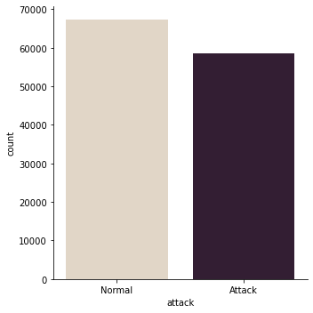

```python
import seaborn as sns

sns.catplot(x="attack", kind="count", palette="ch:.25", data=Y_train.replace(attack_label))
```

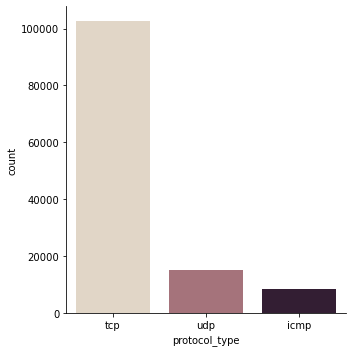

```python
sns.catplot(x="protocol_type", kind="count", palette="ch:.25", data=X_train)
```

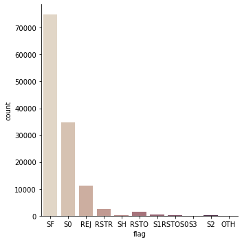

```python
sns.catplot(x="flag", kind="count", palette="ch:.25", data=X_train)
```

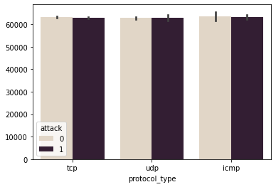

```python
idx = pd.Index(range(1, 125974, 1))
sns.barplot(x="protocol_type", y=idx,hue=Y_train["attack"], palette="ch:.25", data=X_train)
```

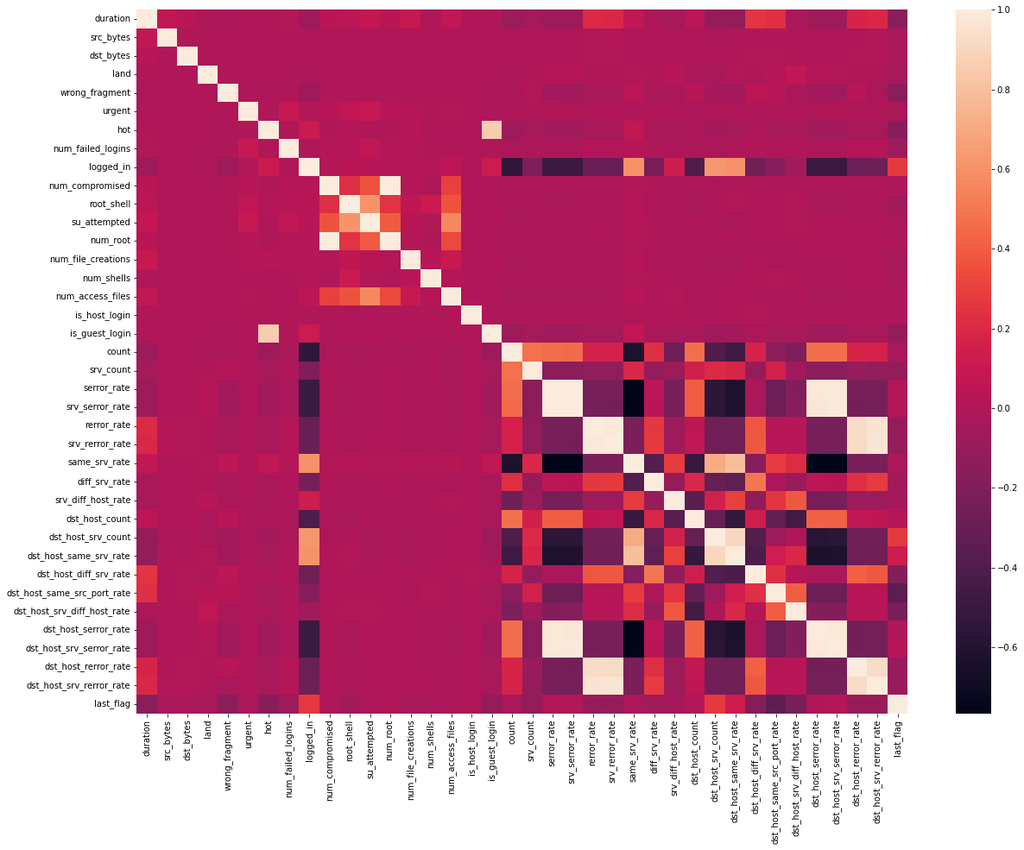

```python
plt.figure(figsize=(20,15))
sns.heatmap(X_train.corr())
```

## Correlation Analysis

```python
df["attack"]=encodeTarget(df["attack"])
#df=oneHotEncoding(df)
#df["attack"]=df["attack"].apply(lambda x:"normal" if x==0 else "attack")
corr = df.corr()
corr_target = abs(corr["attack"])
corr_target
```

```
duration                       0.048785
src_bytes                      0.005921
dst_bytes                      0.004118
land                           0.007191
wrong_fragment                 0.095905
urgent                         0.002787
hot                            0.013083
num_failed_logins              0.003755
logged_in                      0.690171
num_compromised                0.010198
root_shell                     0.020285
su_attempted                   0.022448
num_root                       0.011452
num_file_creations             0.021271
num_shells                     0.009472
num_access_files               0.036701
is_host_login                  0.002629
is_guest_login                 0.039279
count                          0.576444
srv_count                      0.000771
serror_rate                    0.650652
srv_serror_rate                0.648289
rerror_rate                    0.253397
srv_rerror_rate                0.253504
same_srv_rate                  0.751913
diff_srv_rate                  0.203660
srv_diff_host_rate             0.119377
dst_host_count                 0.375052
dst_host_srv_count             0.722535
dst_host_same_srv_rate         0.693803
dst_host_diff_srv_rate         0.242898
dst_host_same_src_port_rate    0.092444
dst_host_srv_diff_host_rate    0.062332
dst_host_serror_rate           0.651842
dst_host_srv_serror_rate       0.654985
dst_host_rerror_rate           0.252563
dst_host_srv_rerror_rate       0.253430
attack                         1.000000
last_flag                      0.379707
Name: attack, dtype: float64
```

## Network Attack and Normal values count

```python
network_Anamoly=Y_train.replace(attack_label)

count_values=dict(Counter(network_Anamoly['attack']))
print("Total Values : ",Y_train['attack'].count())
print("Normal Values : ",count_values['Normal'])
print("Network Attack Values : ",(network_Anamoly['attack'].count()-count_values['Normal']))
network_Anamoly.shape
```

```
Total Values :  125973
Normal Values :  67343
Network Attack Values :  58630
```

```
(125973, 1)
```

## Normalize data

```python
def NormaliseData(data, training=True, rs=None, num_columns=5):
    if training == True:

        from sklearn.preprocessing import StandardScaler
        sc=StandardScaler()
        import joblib
        joblib.dump(sc,"sc.sav")
        rs = sc.fit(data.loc[:,num_columns])

        data.loc[:,num_columns] = rs.transform(data.loc[:,num_columns])
    if training == False and rs !=None:
        data.loc[:,num_columns] = rs.transform(data.loc[:,num_columns])
    return data, rs
X_train_ns, rs=NormaliseData(X_train,num_columns = num_columns)
X_test_ns, rs =NormaliseData(X_test, training=False, rs=rs, num_columns = num_columns)
X_train_ns.shape,X_test_ns.shape
```

```
((125973, 41), (22544, 41))
```

## One hot Encoding on Non target Data

```python
network_ohe_train=pd.get_dummies(X_train_ns,drop_first=True)
network_ohe_test=pd.get_dummies(X_test_ns,drop_first=True)
network_ohe_train.shape,network_ohe_test.shape
```

```
((125973, 119), (22544, 113))
```

```python
network_ohe_train.head()
```

|  | duration | src_bytes | dst_bytes | land | wrong_fragment | urgent | hot | num_failed_logins | logged_in | num_compromised | ... | flag_REJ | flag_RSTO | flag_RSTOS0 | flag_RSTR | flag_S0 | flag_S1 | flag_S2 | flag_S3 | flag_SF | flag_SH |
| --- | --- | --- | --- | --- | --- | --- | --- | --- | --- | --- | --- | --- | --- | --- | --- | --- | --- | --- | --- | --- | --- |
| 0 | -0.110249 | -0.007679 | -0.004919 | -0.014089 | -0.089486 | -0.007736 | -0.095076 | -0.027023 | -0.809262 | -0.011664 | ... | 0 | 0 | 0 | 0 | 0 | 0 | 0 | 0 | 1 | 0 |
| 1 | -0.110249 | -0.007737 | -0.004919 | -0.014089 | -0.089486 | -0.007736 | -0.095076 | -0.027023 | -0.809262 | -0.011664 | ... | 0 | 0 | 0 | 0 | 0 | 0 | 0 | 0 | 1 | 0 |
| 2 | -0.110249 | -0.007762 | -0.004919 | -0.014089 | -0.089486 | -0.007736 | -0.095076 | -0.027023 | -0.809262 | -0.011664 | ... | 0 | 0 | 0 | 0 | 1 | 0 | 0 | 0 | 0 | 0 |
| 3 | -0.110249 | -0.007723 | -0.002891 | -0.014089 | -0.089486 | -0.007736 | -0.095076 | -0.027023 | 1.235694 | -0.011664 | ... | 0 | 0 | 0 | 0 | 0 | 0 | 0 | 0 | 1 | 0 |
| 4 | -0.110249 | -0.007728 | -0.004814 | -0.014089 | -0.089486 | -0.007736 | -0.095076 | -0.027023 | 1.235694 | -0.011664 | ... | 0 | 0 | 0 | 0 | 0 | 0 | 0 | 0 | 1 | 0 |

5 rows × 119 columns

```python
network_ohe_test.head()
```

|  | duration | src_bytes | dst_bytes | land | wrong_fragment | urgent | hot | num_failed_logins | logged_in | num_compromised | ... | flag_REJ | flag_RSTO | flag_RSTOS0 | flag_RSTR | flag_S0 | flag_S1 | flag_S2 | flag_S3 | flag_SF | flag_SH |
| --- | --- | --- | --- | --- | --- | --- | --- | --- | --- | --- | --- | --- | --- | --- | --- | --- | --- | --- | --- | --- | --- |
| 0 | -0.110249 | -0.007762 | -0.004919 | -0.014089 | -0.089486 | -0.007736 | -0.095076 | -0.027023 | -0.809262 | -0.011664 | ... | 1 | 0 | 0 | 0 | 0 | 0 | 0 | 0 | 0 | 0 |
| 1 | -0.110249 | -0.007762 | -0.004919 | -0.014089 | -0.089486 | -0.007736 | -0.095076 | -0.027023 | -0.809262 | -0.011664 | ... | 1 | 0 | 0 | 0 | 0 | 0 | 0 | 0 | 0 | 0 |
| 2 | -0.109481 | -0.005551 | -0.004919 | -0.014089 | -0.089486 | -0.007736 | -0.095076 | -0.027023 | -0.809262 | -0.011664 | ... | 0 | 0 | 0 | 0 | 0 | 0 | 0 | 0 | 1 | 0 |
| 3 | -0.110249 | -0.007759 | -0.004919 | -0.014089 | -0.089486 | -0.007736 | -0.095076 | -0.027023 | -0.809262 | -0.011664 | ... | 0 | 0 | 0 | 0 | 0 | 0 | 0 | 0 | 1 | 0 |
| 4 | -0.109865 | -0.007762 | -0.004915 | -0.014089 | -0.089486 | -0.007736 | -0.095076 | -0.027023 | -0.809262 | -0.011664 | ... | 0 | 1 | 0 | 0 | 0 | 0 | 0 | 0 | 0 | 0 |

5 rows × 113 columns

## Feature Selection

```python
def featureSelect(data,test):
    from sklearn.tree import DecisionTreeClassifier
    model_dt = DecisionTreeClassifier(criterion = 'gini',random_state=500)
    model_dt.fit(data,test)

    print(data.columns[model_dt.feature_importances_ >= 0.001].unique())
    return model_dt

X_train=featureSelect(network_ohe_train,Y_train)

X_test=network_ohe_test[network_ohe_train.columns[X_train.feature_importances_ >= 0.001]]

X_train=network_ohe_train[network_ohe_train.columns[X_train.feature_importances_ >= 0.001]]
X_train
```

```
Index(['src_bytes', 'dst_bytes', 'hot', 'logged_in', 'count', 'serror_rate',
       'dst_host_same_srv_rate', 'dst_host_srv_diff_host_rate',
       'dst_host_srv_serror_rate', 'last_flag', 'protocol_type_tcp',
       'service_ecr_i', 'service_http', 'service_other', 'flag_S0', 'flag_S1'],
      dtype='object')
```

|  | src_bytes | dst_bytes | hot | logged_in | count | serror_rate | dst_host_same_srv_rate | dst_host_srv_diff_host_rate | dst_host_srv_serror_rate | last_flag | protocol_type_tcp | service_ecr_i | service_http | service_other | flag_S0 | flag_S1 |
| --- | --- | --- | --- | --- | --- | --- | --- | --- | --- | --- | --- | --- | --- | --- | --- | --- |
| 0 | -0.007679 | -0.004919 | -0.095076 | -0.809262 | -0.717045 | -0.637209 | -0.782367 | -0.289103 | -0.624871 | 0.216426 | 1 | 0 | 0 | 0 | 0 | 0 |
| 1 | -0.007737 | -0.004919 | -0.095076 | -0.809262 | -0.620982 | -0.637209 | -1.161030 | -0.289103 | -0.624871 | -1.965556 | 0 | 0 | 0 | 1 | 0 | 0 |
| 2 | -0.007762 | -0.004919 | -0.095076 | -0.809262 | 0.339648 | 1.602664 | -0.938287 | -0.289103 | 1.618955 | -0.219970 | 1 | 0 | 0 | 0 | 1 | 0 |
| 3 | -0.007723 | -0.002891 | -0.095076 | 1.235694 | -0.690846 | -0.189235 | 1.066401 | 0.066252 | -0.602433 | 0.652823 | 1 | 0 | 1 | 0 | 0 | 0 |
| 4 | -0.007728 | -0.004814 | -0.095076 | 1.235694 | -0.472521 | -0.637209 | 1.066401 | -0.289103 | -0.624871 | 0.652823 | 1 | 0 | 1 | 0 | 0 | 0 |
| ... | ... | ... | ... | ... | ... | ... | ... | ... | ... | ... | ... | ... | ... | ... | ... | ... |
| 125968 | -0.007762 | -0.004919 | -0.095076 | -0.809262 | 0.872361 | 1.602664 | -0.938287 | -0.289103 | 1.618955 | 0.216426 | 1 | 0 | 0 | 0 | 1 | 0 |
| 125969 | -0.007744 | -0.004883 | -0.095076 | -0.809262 | -0.717045 | -0.637209 | 0.977304 | -0.289103 | -0.624871 | 0.652823 | 0 | 0 | 0 | 0 | 0 | 0 |
| 125970 | -0.007382 | -0.004823 | -0.095076 | 1.235694 | -0.725778 | -0.637209 | -0.893738 | -0.289103 | -0.624871 | -0.656367 | 1 | 0 | 0 | 0 | 0 | 0 |
| 125971 | -0.007762 | -0.004919 | -0.095076 | -0.809262 | 0.523041 | 1.602664 | -1.094207 | -0.289103 | 1.618955 | 0.216426 | 1 | 0 | 0 | 0 | 1 | 0 |
| 125972 | -0.007737 | -0.004919 | -0.095076 | 1.235694 | -0.725778 | -0.637209 | -0.492801 | -0.289103 | -0.624871 | 0.652823 | 1 | 0 | 0 | 0 | 0 | 0 |

125973 rows × 16 columns

### From Columns like

'src_bytes', 'dst_bytes', 'hot', 'logged_in', 'count', 'serror_rate', 'dst_host_same_srv_rate', 'dst_host_srv_diff_host_rate', 'dst_host_srv_serror_rate', 'last_flag', 'protocol_type_tcp', 'service_ecr_i', 'service_http', 'service_other', 'flag_S0', 'flag_S1'

#### we can determine is our network under attack or not We can do Binomial Classification on it .

```python
X_train.columns.nunique()
```

```
16
```

```python
X_test.head()
```

|  | src_bytes | dst_bytes | hot | logged_in | count | serror_rate | dst_host_same_srv_rate | dst_host_srv_diff_host_rate | dst_host_srv_serror_rate | last_flag | protocol_type_tcp | service_ecr_i | service_http | service_other | flag_S0 | flag_S1 |
| --- | --- | --- | --- | --- | --- | --- | --- | --- | --- | --- | --- | --- | --- | --- | --- | --- |
| 0 | -0.007762 | -0.004919 | -0.095076 | -0.809262 | 1.265346 | -0.637209 | -1.071933 | -0.289103 | -0.624871 | 0.652823 | 1 | 0 | 0 | 0 | 0 | 0 |
| 1 | -0.007762 | -0.004919 | -0.095076 | -0.809262 | 0.453177 | -0.637209 | -1.161030 | -0.289103 | -0.624871 | 0.652823 | 1 | 0 | 0 | 0 | 0 | 0 |
| 2 | -0.005551 | -0.004919 | -0.095076 | -0.809262 | -0.725778 | -0.637209 | 0.197703 | -0.111426 | -0.624871 | 0.652823 | 1 | 0 | 0 | 0 | 0 | 0 |
| 3 | -0.007759 | -0.004919 | -0.095076 | -0.809262 | -0.725778 | -0.637209 | 1.066401 | 2.198385 | -0.624871 | -1.965556 | 0 | 0 | 0 | 0 | 0 | 0 |
| 4 | -0.007762 | -0.004915 | -0.095076 | -0.809262 | -0.725778 | -0.637209 | -0.470526 | -0.111426 | -0.624871 | -3.711143 | 1 | 0 | 0 | 0 | 0 | 0 |

## Evaluate all modes

```python
def eval_model(Y_test,Y_predict):
    from sklearn.metrics import accuracy_score,f1_score,precision_score,recall_score
    f1=f1_score(Y_test,Y_predict)
    prec=precision_score(Y_test,Y_predict)
    recall=recall_score(Y_test,Y_predict)
  # Calculate Confusion Matrix
  #cf_mat=confusion_matrix(Y_test,Y_predict)


  # Calculate Accuracy
    acc = accuracy_score(Y_test,Y_predict)
    return f1,prec,recall, acc
```

```
<class 'sklearn.linear_model._logistic.LogisticRegression'>
```

```
F1 Score : 0.8682464454976303
Precision :  0.9214485654303709
Recall :  0.8208524896750565
Accuracy :  0.8581884315117104
```

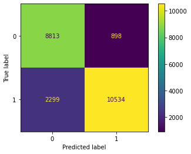

```
<class 'sklearn.tree._classes.DecisionTreeClassifier'>
F1 Score : 0.832148128270495
Precision :  0.9765903842116314
Recall :  0.7249279202057196
Accuracy :  0.8335255500354861
```

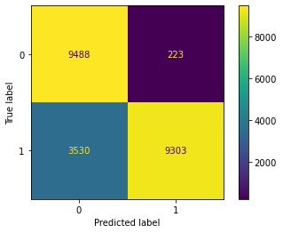

```
<class 'sklearn.ensemble._forest.RandomForestClassifier'>
```

```
F1 Score : 0.8231433195468442
Precision :  0.9727977898204229
Recall :  0.7133951531208603
Accuracy :  0.8254968062455642
```

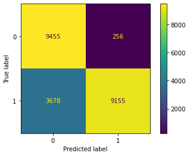

```
<class 'sklearn.svm._classes.SVC'>
```

```
F1 Score : 0.846829607723754
Precision :  0.9581734081291211
Recall :  0.7586690563391257
Accuracy :  0.8437721788502484
```

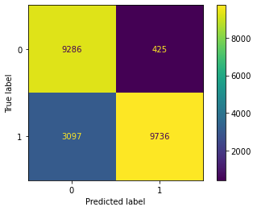

```
<class 'sklearn.ensemble._weight_boosting.AdaBoostClassifier'>
```

```
F1 Score : 0.8170093795093795
Precision :  0.9696029112704698
Recall :  0.7059144393360867
Accuracy :  0.8199964513839603
```

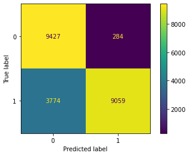

```
<class 'catboost.core.CatBoostClassifier'>
Learning rate set to 0.081237
F1 Score : 0.8487221220252495
Precision :  0.9744444444444444
Recall :  0.7517338112678251
Accuracy :  0.8474538679914834
```

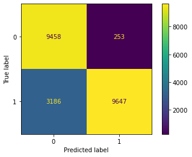

```
<class 'xgboost.sklearn.XGBClassifier'>
[09:02:27] WARNING: D:\bld\xgboost-split_1645118015404\work\src\learner.cc:1115: Starting in XGBoost 1.3.0, the default evaluation metric used with the objective 'binary:logistic' was changed from 'error' to 'logloss'. Explicitly set eval_metric if you'd like to restore the old behavior.
```

```
F1 Score : 0.8294386247649744
Precision :  0.9746449237243556
Recall :  0.7218888802306553
Accuracy :  0.8309971611071683
```

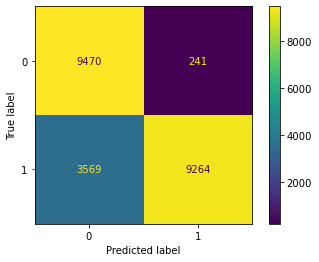

```
<class 'sklearn.ensemble._gb.GradientBoostingClassifier'>
```

```
F1 Score : 0.8456299160697807
Precision :  0.9695687222893994
Recall :  0.749785708719707
Accuracy :  0.8441713981547196
```

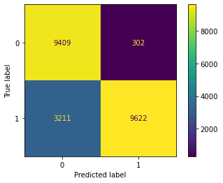

```python
from sklearn.ensemble import RandomForestClassifier
from sklearn.tree import DecisionTreeClassifier
from sklearn.ensemble import AdaBoostClassifier
from sklearn.ensemble import GradientBoostingClassifier
from catboost import CatBoostClassifier
from sklearn.linear_model import LogisticRegression
from sklearn.svm import SVC

from xgboost import XGBClassifier
import joblib
from sklearn.metrics import plot_confusion_matrix
import matplotlib.pyplot as plt

## Creating Model List
model_list = [LogisticRegression(),DecisionTreeClassifier(),RandomForestClassifier(),SVC(),
              AdaBoostClassifier(),CatBoostClassifier(),XGBClassifier(),GradientBoostingClassifier()]


for model in model_list:
    print(model.__class__)
  # train the model
    model.fit(X_train,Y_train)
    Y_pred_train=model.predict(X_train)

  # test the model on X_test
    Y_predict = model.predict(X_test)

    ## Saving model
    model_name = type(model).__name__
    model_save=model_name+"StdSc.sav"
    joblib.dump(model,model_save)

    ## Evaluating Model
    f1,prec,recall, acc = eval_model(Y_test,Y_predict)

    #Print Results
    print("F1 Score :",f1)
    print("Precision : ",prec)
    print("Recall : ",recall)
    print("Accuracy : ",acc)

    plot_confusion_matrix(model, X_test, Y_test)
    plt.show()
    print("***************************")
    print()
```

## Applying ANN(Artificial Neural Network)

```python
n_features = X_train.shape[1]
n_features
```

```
16
```

```python
from tensorflow.keras import Sequential
from tensorflow.keras.layers import Dense
from keras.callbacks import EarlyStopping
model1 = Sequential()
model1.add(Dense(64, activation='relu', input_shape=(n_features,)))
model1.add(Dense(32, activation='relu'))
model1.add(Dense(32, activation='relu'))
model1.add(Dense(64, activation='relu'))
model1.add(Dense(32, activation='relu'))
##increased acc after this
model1.add(Dense(64, activation='relu'))
model1.add(Dense(10, activation='relu'))

#model1.add(Dense(64, activation='relu'))
#model1.add(Dense(10, activation='relu'))



# model1.add(Dense(8, activation='relu'))
model1.add(Dense(1, activation='sigmoid'))
```

```python
model1.summary()
```

```
Model: "sequential"
_________________________________________________________________
 Layer (type)                Output Shape              Param #
=================================================================
 dense (Dense)               (None, 64)                1088

 dense_1 (Dense)             (None, 32)                2080

 dense_2 (Dense)             (None, 32)                1056

 dense_3 (Dense)             (None, 64)                2112

 dense_4 (Dense)             (None, 32)                2080

 dense_5 (Dense)             (None, 64)                2112

 dense_6 (Dense)             (None, 10)                650

 dense_7 (Dense)             (None, 1)                 11

=================================================================
Total params: 11,189
Trainable params: 11,189
Non-trainable params: 0
_________________________________________________________________
```

## Compiling ANN model

```python
# compile the model
model1.compile(optimizer='adam', loss='binary_crossentropy', metrics=['accuracy']) # mse mae
```

```python
es = EarlyStopping(monitor='loss', mode='min',patience=5, verbose=1)
```

```python
# fit the model (traning)
history = model1.fit( X_train, Y_train, epochs=200,validation_split=0.3, batch_size=128, verbose=2,callbacks=[es],shuffle=False)
```

```
689/689 - 4s - loss: 0.0740 - accuracy: 0.9788 - val_loss: 0.0302 - val_accuracy: 0.9890 - 4s/epoch - 5ms/step
689/689 - 2s - loss: 0.0297 - accuracy: 0.9886 - val_loss: 0.0256 - val_accuracy: 0.9905 - 2s/epoch - 3ms/step
689/689 - 2s - loss: 0.0264 - accuracy: 0.9896 - val_loss: 0.0236 - val_accuracy: 0.9911 - 2s/epoch - 3ms/step
689/689 - 2s - loss: 0.0247 - accuracy: 0.9902 - val_loss: 0.0228 - val_accuracy: 0.9915 - 2s/epoch - 3ms/step
689/689 - 2s - loss: 0.0236 - accuracy: 0.9907 - val_loss: 0.0222 - val_accuracy: 0.9920 - 2s/epoch - 3ms/step
689/689 - 2s - loss: 0.0239 - accuracy: 0.9906 - val_loss: 0.0221 - val_accuracy: 0.9923 - 2s/epoch - 3ms/step
689/689 - 2s - loss: 0.0214 - accuracy: 0.9913 - val_loss: 0.0215 - val_accuracy: 0.9922 - 2s/epoch - 3ms/step
689/689 - 2s - loss: 0.0207 - accuracy: 0.9916 - val_loss: 0.0208 - val_accuracy: 0.9925 - 2s/epoch - 3ms/step
689/689 - 2s - loss: 0.0201 - accuracy: 0.9917 - val_loss: 0.0202 - val_accuracy: 0.9930 - 2s/epoch - 3ms/step
689/689 - 2s - loss: 0.0196 - accuracy: 0.9921 - val_loss: 0.0199 - val_accuracy: 0.9929 - 2s/epoch - 3ms/step
689/689 - 2s - loss: 0.0192 - accuracy: 0.9921 - val_loss: 0.0194 - val_accuracy: 0.9930 - 2s/epoch - 3ms/step
689/689 - 2s - loss: 0.0186 - accuracy: 0.9924 - val_loss: 0.0189 - val_accuracy: 0.9931 - 2s/epoch - 3ms/step
689/689 - 2s - loss: 0.0184 - accuracy: 0.9924 - val_loss: 0.0192 - val_accuracy: 0.9931 - 2s/epoch - 3ms/step
689/689 - 2s - loss: 0.0181 - accuracy: 0.9925 - val_loss: 0.0190 - val_accuracy: 0.9935 - 2s/epoch - 3ms/step
689/689 - 2s - loss: 0.0177 - accuracy: 0.9926 - val_loss: 0.0193 - val_accuracy: 0.9936 - 2s/epoch - 3ms/step
689/689 - 2s - loss: 0.0176 - accuracy: 0.9926 - val_loss: 0.0195 - val_accuracy: 0.9938 - 2s/epoch - 3ms/step
689/689 - 2s - loss: 0.0178 - accuracy: 0.9927 - val_loss: 0.0190 - val_accuracy: 0.9937 - 2s/epoch - 3ms/step
689/689 - 2s - loss: 0.0173 - accuracy: 0.9928 - val_loss: 0.0184 - val_accuracy: 0.9938 - 2s/epoch - 3ms/step
689/689 - 2s - loss: 0.0172 - accuracy: 0.9929 - val_loss: 0.0189 - val_accuracy: 0.9936 - 2s/epoch - 3ms/step
689/689 - 2s - loss: 0.0169 - accuracy: 0.9929 - val_loss: 0.0181 - val_accuracy: 0.9942 - 2s/epoch - 3ms/step
689/689 - 2s - loss: 0.0164 - accuracy: 0.9933 - val_loss: 0.0184 - val_accuracy: 0.9938 - 2s/epoch - 3ms/step
689/689 - 2s - loss: 0.0162 - accuracy: 0.9932 - val_loss: 0.0181 - val_accuracy: 0.9938 - 2s/epoch - 3ms/step
689/689 - 2s - loss: 0.0170 - accuracy: 0.9931 - val_loss: 0.0180 - val_accuracy: 0.9939 - 2s/epoch - 3ms/step
689/689 - 2s - loss: 0.0161 - accuracy: 0.9930 - val_loss: 0.0182 - val_accuracy: 0.9936 - 2s/epoch - 3ms/step
689/689 - 2s - loss: 0.0163 - accuracy: 0.9932 - val_loss: 0.0175 - val_accuracy: 0.9942 - 2s/epoch - 3ms/step
689/689 - 2s - loss: 0.0161 - accuracy: 0.9932 - val_loss: 0.0173 - val_accuracy: 0.9939 - 2s/epoch - 3ms/step
689/689 - 2s - loss: 0.0162 - accuracy: 0.9933 - val_loss: 0.0180 - val_accuracy: 0.9940 - 2s/epoch - 3ms/step
689/689 - 2s - loss: 0.0156 - accuracy: 0.9933 - val_loss: 0.0189 - val_accuracy: 0.9940 - 2s/epoch - 3ms/step
689/689 - 2s - loss: 0.0156 - accuracy: 0.9934 - val_loss: 0.0184 - val_accuracy: 0.9938 - 2s/epoch - 3ms/step
689/689 - 2s - loss: 0.0153 - accuracy: 0.9932 - val_loss: 0.0193 - val_accuracy: 0.9933 - 2s/epoch - 3ms/step
689/689 - 2s - loss: 0.0155 - accuracy: 0.9935 - val_loss: 0.0180 - val_accuracy: 0.9939 - 2s/epoch - 3ms/step
689/689 - 2s - loss: 0.0151 - accuracy: 0.9935 - val_loss: 0.0176 - val_accuracy: 0.9942 - 2s/epoch - 3ms/step
689/689 - 2s - loss: 0.0158 - accuracy: 0.9936 - val_loss: 0.0184 - val_accuracy: 0.9940 - 2s/epoch - 3ms/step
689/689 - 2s - loss: 0.0150 - accuracy: 0.9937 - val_loss: 0.0190 - val_accuracy: 0.9940 - 2s/epoch - 3ms/step
689/689 - 2s - loss: 0.0150 - accuracy: 0.9939 - val_loss: 0.0177 - val_accuracy: 0.9940 - 2s/epoch - 3ms/step
689/689 - 2s - loss: 0.0146 - accuracy: 0.9938 - val_loss: 0.0172 - val_accuracy: 0.9945 - 2s/epoch - 3ms/step
689/689 - 2s - loss: 0.0145 - accuracy: 0.9938 - val_loss: 0.0173 - val_accuracy: 0.9941 - 2s/epoch - 3ms/step
689/689 - 2s - loss: 0.0145 - accuracy: 0.9935 - val_loss: 0.0169 - val_accuracy: 0.9945 - 2s/epoch - 3ms/step
689/689 - 2s - loss: 0.0146 - accuracy: 0.9936 - val_loss: 0.0181 - val_accuracy: 0.9944 - 2s/epoch - 3ms/step
```

[output cut: 20 more lines]

## Evaluate Model

```python
# evaluate the model
loss, acc = model1.evaluate(X_test, Y_test, verbose=0)
print('Test Accuracy: %.3f' % acc)
```

```
Test Accuracy: 0.864
```

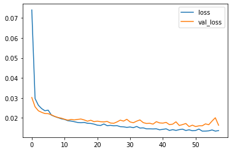

```python
import matplotlib.pyplot as plt
plt.plot(history.history['loss'])
plt.plot(history.history['val_loss'])
plt.legend(["loss","val_loss"])
```

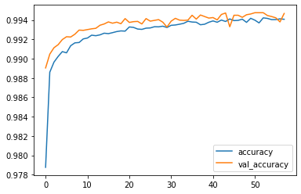

```python
plt.plot(history.history['accuracy'])
plt.plot(history.history['val_accuracy'])
plt.legend(["accuracy","val_accuracy"])
```

```python
from sklearn.metrics import classification_report
y_predicted = model1.predict(X_test)
y_predicted = np.round(y_predicted)
print("Classification Report: \n", classification_report(y_predicted,Y_test))
```

```
Classification Report:
               precision    recall  f1-score   support

         0.0       0.96      0.78      0.86     11974
         1.0       0.79      0.96      0.87     10570

    accuracy                           0.86     22544
   macro avg       0.88      0.87      0.86     22544
weighted avg       0.88      0.86      0.86     22544
```

```python
model1.save("ANN.h5")
```

## Adaboost FineTuning

```
Fitting 3 folds for each of 12 candidates, totalling 36 fits
```

```
[CV] END base_estimator=DecisionTreeClassifier(), learning_rate=0.1, n_estimators=100; total time=  42.6s
```

```
[CV] END base_estimator=DecisionTreeClassifier(), learning_rate=0.1, n_estimators=100; total time= 1.2min
```

```
[CV] END base_estimator=DecisionTreeClassifier(), learning_rate=0.1, n_estimators=100; total time=  33.7s
```

```
[CV] END base_estimator=DecisionTreeClassifier(), learning_rate=0.1, n_estimators=150; total time= 1.4min
```

```
[CV] END base_estimator=DecisionTreeClassifier(), learning_rate=0.1, n_estimators=150; total time= 2.4min
```

```
[CV] END base_estimator=DecisionTreeClassifier(), learning_rate=0.1, n_estimators=150; total time=  55.1s
```

```
[CV] END base_estimator=DecisionTreeClassifier(), learning_rate=0.1, n_estimators=200; total time= 1.8min
```

```
[CV] END base_estimator=DecisionTreeClassifier(), learning_rate=0.1, n_estimators=200; total time= 2.5min
```

```
[CV] END base_estimator=DecisionTreeClassifier(), learning_rate=0.1, n_estimators=200; total time= 1.1min
```

```
[CV] END base_estimator=DecisionTreeClassifier(), learning_rate=0.09, n_estimators=100; total time=  17.3s
```

```
[CV] END base_estimator=DecisionTreeClassifier(), learning_rate=0.09, n_estimators=100; total time=  46.5s
```

```
[CV] END base_estimator=DecisionTreeClassifier(), learning_rate=0.09, n_estimators=100; total time=  23.2s
```

```
[CV] END base_estimator=DecisionTreeClassifier(), learning_rate=0.09, n_estimators=150; total time=  26.1s
```

```
[CV] END base_estimator=DecisionTreeClassifier(), learning_rate=0.09, n_estimators=150; total time= 1.5min
```

```
[CV] END base_estimator=DecisionTreeClassifier(), learning_rate=0.09, n_estimators=150; total time=  34.5s
```

```
[CV] END base_estimator=DecisionTreeClassifier(), learning_rate=0.09, n_estimators=200; total time=  37.8s
```

```
[CV] END base_estimator=DecisionTreeClassifier(), learning_rate=0.09, n_estimators=200; total time= 2.0min
```

```
[CV] END base_estimator=DecisionTreeClassifier(), learning_rate=0.09, n_estimators=200; total time=  48.1s
```

```
[CV] END base_estimator=DecisionTreeClassifier(), learning_rate=0.9, n_estimators=100; total time=  12.8s
```

```
[CV] END base_estimator=DecisionTreeClassifier(), learning_rate=0.9, n_estimators=100; total time=  28.8s
```

```
[CV] END base_estimator=DecisionTreeClassifier(), learning_rate=0.9, n_estimators=100; total time=  20.8s
```

```
[CV] END base_estimator=DecisionTreeClassifier(), learning_rate=0.9, n_estimators=150; total time=  20.1s
```

```
[CV] END base_estimator=DecisionTreeClassifier(), learning_rate=0.9, n_estimators=150; total time=  47.9s
```

```
[CV] END base_estimator=DecisionTreeClassifier(), learning_rate=0.9, n_estimators=150; total time=  37.2s
```

```
[CV] END base_estimator=DecisionTreeClassifier(), learning_rate=0.9, n_estimators=200; total time=  27.8s
```

```
[CV] END base_estimator=DecisionTreeClassifier(), learning_rate=0.9, n_estimators=200; total time=  59.8s
```

```
[CV] END base_estimator=DecisionTreeClassifier(), learning_rate=0.9, n_estimators=200; total time=  46.1s
```

```
[CV] END base_estimator=DecisionTreeClassifier(), learning_rate=0.01, n_estimators=100; total time=  35.3s
```

```
[CV] END base_estimator=DecisionTreeClassifier(), learning_rate=0.01, n_estimators=100; total time=  37.6s
```

```
[CV] END base_estimator=DecisionTreeClassifier(), learning_rate=0.01, n_estimators=100; total time=  35.5s
```

```
[CV] END base_estimator=DecisionTreeClassifier(), learning_rate=0.01, n_estimators=150; total time=  53.5s
```

```
[CV] END base_estimator=DecisionTreeClassifier(), learning_rate=0.01, n_estimators=150; total time=  55.2s
```

```
[CV] END base_estimator=DecisionTreeClassifier(), learning_rate=0.01, n_estimators=150; total time=  52.6s
```

```
[CV] END base_estimator=DecisionTreeClassifier(), learning_rate=0.01, n_estimators=200; total time= 1.1min
```

```
[CV] END base_estimator=DecisionTreeClassifier(), learning_rate=0.01, n_estimators=200; total time= 1.2min
```

```
[CV] END base_estimator=DecisionTreeClassifier(), learning_rate=0.01, n_estimators=200; total time= 1.2min
```

```
{'base_estimator': DecisionTreeClassifier(), 'learning_rate': 0.01, 'n_estimators': 100}
[0.99877752 0.99849174 0.99853937 0.99872195 0.99865844 0.99861081
 0.99881721 0.99884896 0.9988569  0.99897597 0.99882515 0.99878545]
0.9987424553938807
F1 Score : 0.8350436925834641
Precision :  0.9825986078886311
Recall :  0.7260188576326658
Accuracy :  0.8367193044712562
```

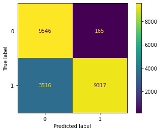

```
['Adboost_SC2.sav']
```

```python
from sklearn.model_selection import GridSearchCV
from sklearn.tree import DecisionTreeClassifier
param_grid = {
    'n_estimators': [100,150,200],
    'base_estimator' : [DecisionTreeClassifier()],
    'learning_rate':[0.1,0.09,0.9,0.01],
    }

ada = AdaBoostClassifier(random_state=500)

CV_abc = GridSearchCV(estimator=ada, param_grid=param_grid,\

                       cv=3,verbose=2)

CV_abc.fit(X_train, Y_train)

print(CV_abc.best_params_)
print(CV_abc.cv_results_['mean_test_score'])
print(sum(CV_abc.cv_results_['mean_test_score'])/ len(CV_abc.cv_results_['mean_test_score']))


Y_predict = CV_abc.predict(X_test)


f1,prec,recall, acc = eval_model(Y_test,Y_predict)
print("F1 Score :",f1)
print("Precision : ",prec)
print("Recall : ",recall)
print("Accuracy : ",acc)

plot_confusion_matrix(CV_abc, X_test, Y_test)
plt.show()
joblib.dump(CV_abc,"Adboost_SC2.sav")
```

## Finetunning Catboost

```
Fitting 3 folds for each of 7 candidates, totalling 21 fits
{'depth': 7, 'learning_rate': 0.02, 'n_estimators': 1500}
[0.99907917 0.99897597 0.99897597 0.99880133 0.99906329 0.99911886
 0.99880133]
0.9989737029817048
F1 Score : 0.8506151142355008
Precision :  0.9751183640576206
Recall :  0.7543053066313411
Accuracy :  0.8491838183108588
```

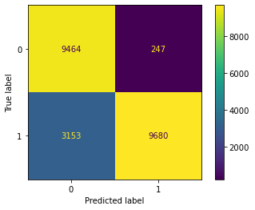

```
['Catboost_SC.sav']
```

```python
from sklearn.model_selection import GridSearchCV
from sklearn.tree import DecisionTreeClassifier
from catboost import CatBoostClassifier
param_grid = {
    'n_estimators': [1500],

    'learning_rate':[0.1,0.2,0.09,0.9,0.01,0.02,1.1],
    #'iterations':[100],

    'depth':[7],


}
cat = CatBoostClassifier(random_state=500)

CV_cat = GridSearchCV(estimator=cat, param_grid=param_grid,\

                       cv=3,verbose=2)

CV_cat.fit(X_train, Y_train)

print(CV_cat.best_params_)
print(CV_cat.cv_results_['mean_test_score'])
print(sum(CV_cat.cv_results_['mean_test_score'])/ len(CV_cat.cv_results_['mean_test_score']))


Y_predict = CV_cat.predict(X_test)

#ada=AdaBoostClassifier(n_estimators=72,algorithm='SAMME',learning_rate=1.1)
#ada.fit(X_train,Y_train)
#Y_pred_train=ada.predict(X_train)


  # test the model So give on known data (X_test)
    #model_dt_test, Y_test

#Y_predict = ada.predict(model_dt_test)
f1,prec,recall, acc = eval_model(Y_test,Y_predict)

print("F1 Score :",f1)
print("Precision : ",prec)
print("Recall : ",recall)
print("Accuracy : ",acc)
plot_confusion_matrix(CV_cat, X_test, Y_test)
plt.show()
joblib.dump(CV_cat,"Catboost_SC.sav")
```